# BIOL-607 Biological Data Analysis Homework 3: Data Visualization

Andrew Judell-Halfpenny

September 27, 2018

## Libraries Used

```r
# load the libraries and the abd dat
library(devtools)
#devtools::install_github(gganimate)
#devtools::install_github(phangorn)
#devtools::install_github(treeio)
#library(ggvis);library(phangorn)
#library(ggtree);library(treeio);

#1. load libraries
library(tidyr);library(tidygraph);library(lubridate)
library(ggplot2);library(animation);library(readr)
library(abd);library(dplyr);library(magrittr)
library(forcats)
```

## For the first three problems, consider the data from problem 9 on page 109

### 1) Complete problems 10 and 17-18 on pg. 109-111. Use R where possible. Using an approximate method, provide a rough 95% confidence interval for the population mean.

```r
abd.genes<-read.csv(url("http://whitlockschluter.zoology.ubc.ca/wp-content/data/chapter04/chap04e1HumanGeneLengths.csv"))
abd.genes<-as.matrix(abd.genes)

# standard error function
std.er <- function(x){
  output <-sd(x)/sqrt(length(x))
  return(output)}
abd.std.er<-std.er(abd.genes)
abd.mean<-mean(abd.genes)

# This is the standard eror variable
abd.std.er
```

```
## [1] 14.30023
```

```r
# This is the sample mean
abd.mean
```

```
## [1] 2622.027
```

```r
l.abs.genes=abd.mean - 2 * abd.std.er
h.abs.genes=abd.mean + 2 * abd.std.er

# This variable serves as the lower bound of the 95% confidence interval
l.abs.genes
```

```
## [1] 2593.427
```

```r
# This variable serves as the upper bound of the 95% confidence interval
h.abs.genes
```

```
## [1] 2650.628
```

## Answer:

### No this is statement belies a misunderstanding of the nature of a confidence interval. The 95% confidence interval is not integrated over the area of a probability densityy function therefor it is not possible to calculate the probability that the true population parameter mean for a subset or slice of the original field.

### 18 Amorphophallus johnsonii is a plant growing in West Africa, and it is better known as a “corpse-flower.” Its common name comes from the fact that when it flowers, it gives off a “powerful aroma of rotting fish and faeces” (Beath 1996). The flowers smell this way because their principal pollinators are carrion beetles, who are attracted to such a smell. Beath (1996) observed the number of carrion beetles (Phaeochrous amplus) that arrive per night to flowers of this species. The data are as follows:

```r
dung_visits<-c(51, 45, 61, 76, 11, 117, 7, 132, 52, 149)
dung_visits<-as.matrix(dung_visits)
```

### 18 a) What is the mean and standard deviation of beetles per flower?

```r
mean_dung_vists<-mean(dung_visits)
mean_dung_vists
```

```
## [1] 70.1
```

### 18 b) What is the standard error of this estimate of the mean?

```r
sd(dung_visits)
```

```
## [1] 48.50074
```

```r
str(dung_visits)
```

```
##  num [1:10, 1] 51 45 61 76 11 117 7 132 52 149
```

```r
visit.st.er<-std.er(dung_visits)
```

### 18 c) Give an approximate 95% confidence interval of the mean. Provide lower and upper limits.

```r
mean_dung_vists + 2 * visit.st.er
```

```
## [1] 100.7746
```

```r
mean_dung_vists - 2 * visit.st.er
```

```
## [1] 39.42544
```

### 18 f) If you had been given 25 data points instead of 10, would you have expected the standard error to be greater, less than, or about the same as this sample?

## Answer: The standard error can be expected to decrease after resampling with a grater population. This is because with a larger sample the calculation of the true mean is more precice. The true meaan and standard deviation.

### 2.1) Load the data using readr and make the Month_Names column into a factor whose levels are in order of month using forcats::fct_inorder. Use levels() - a function that takes a factor vector and returns the unique levels - on the column. Are they in the right order?

```r
NHice<-readr::read_csv("/home/drew/Downloads/BIOL607-Biological-Data-Analysis/week-03/NH_seaice_extent_monthly_1978_2016.csv")
NHice$monthfactor<-factor(NHice$Month_Name,levels=month.abb, ordered=TRUE)
levels(NHice$monthfactor)
```

```
##  [1] "Jan" "Feb" "Mar" "Apr" "May" "Jun" "Jul" "Aug" "Sep" "Oct" "Nov"
## [12] "Dec"
```

```r
NHice$inorder<-fct_inorder(NHice$monthfactor, ordered=TRUE)
levels(NHice$inorder)
```

```
##  [1] "Nov" "Dec" "Feb" "Mar" "Jun" "Jul" "Sep" "Oct" "Jan" "Apr" "May"
## [12] "Aug"
```

### 2.2) Try fct_rev() on ice$Month_Name (I called my data frame ice when I made this). What is the order of factor levels that results? Try out fct_relevel(), and last, fct_recode() as well. Look at the help files to learn more, and in particular try out the examples. Use these to guide how you try each functino out. After trying each of these, mutate month name to get the months in the right order, from January to December. Show that it worked with levels()

```r
levels(fct_rev(NHice$Month_Name))
```

```
##  [1] "Sep" "Oct" "Nov" "May" "Mar" "Jun" "Jul" "Jan" "Feb" "Dec" "Aug"
## [12] "Apr"
```

```r
levels(fct_relevel(NHice$Month_Name))
```

```
##  [1] "Apr" "Aug" "Dec" "Feb" "Jan" "Jul" "Jun" "Mar" "May" "Nov" "Oct"
## [12] "Sep"
```

```r
levels(fct_recode(NHice$Month_Name))
```

```
##  [1] "Apr" "Aug" "Dec" "Feb" "Jan" "Jul" "Jun" "Mar" "May" "Nov" "Oct"
## [12] "Sep"
```

```r
NHice$monthfactor<-factor(NHice$Month_Name,levels=month.abb, ordered=TRUE)
levels(NHice$monthfactor)
```

```
##  [1] "Jan" "Feb" "Mar" "Apr" "May" "Jun" "Jul" "Aug" "Sep" "Oct" "Nov"
## [12] "Dec"
```

```r
head(NHice)
```

```
## # A tibble: 6 x 8
##    Year Month   Day Extent Missing Month_Name monthfactor inorder
##   <int> <int> <int>  <dbl>   <int> <chr>      <ord>       <ord>
## 1  1978    11     1   10.7       0 Nov        Nov         Nov
## 2  1978    12     1   12.7       0 Dec        Dec         Dec
## 3  1979     2     1   15.9       0 Feb        Feb         Feb
## 4  1979     3     1   16.6       0 Mar        Mar         Mar
## 5  1979     6     1   13.1       0 Jun        Jun         Jun
## 6  1979     7     1   11.6       0 Jul        Jul         Jul
```

### 2.3) Now, using what you have just learned about forcats, make a column called Season that is a copy of Month_Name. Use the function fct_recode to turn it into a factor vector with the levels Winter, Spring, Summer, Fall in that order. Use levels() on ice$Season to show that it worked.

```r
NHice$season<-fct_collapse(NHice$monthfactor,Winter=c("Dec","Jan", "Feb"),Spring=c("Mar","Apr", "May"), Summer=c("Jun", "Jul", "Aug"), Fall=c("Sep", "Oct", "Nov"))
levels(NHice$season)
```

```
## [1] "Winter" "Spring" "Summer" "Fall"
```

### 2.4) Make a boxplot showing the variability in sea ice extent every month.

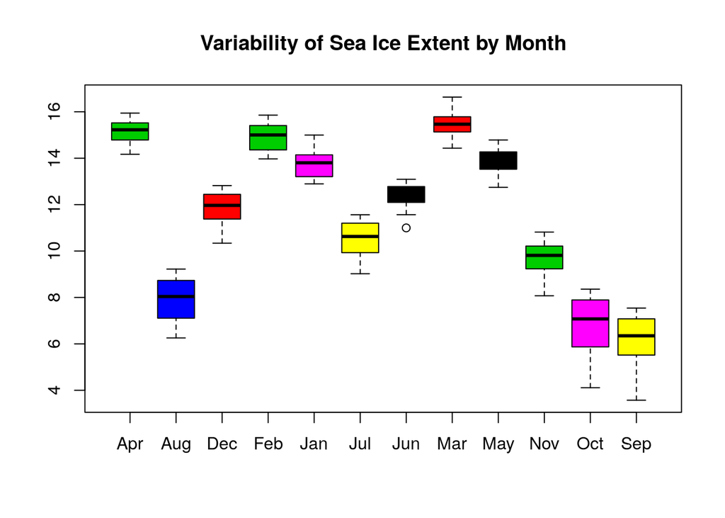

```r
boxplot(Extent ~ Month_Name, data = NHice, col = NHice$Month,main="Variability of Sea Ice Extent by Month")
```